# Hopkins v2 county MMR data: comparisons behind our questions

- Show All Code
- Hide All Code
- View Source

Wisconsin, Kentucky, Indiana and Idaho

Author

Bevin Manuelpillai, Emory University

Published

November 18, 2026

This code that reproduces the comparisons in the email. Each section compares the v2 county values with an independent source: the Wisconsin Department of Health Services (DHS) county file, or CDC SchoolVaxView state estimates.

```r
library(tidyverse)
library(knitr)

# Every input is read by URL, so the note renders anywhere with internet access.
# Small files we host: github.com/bmanuelpillai/hopkins-v2-checks (data/).
data_url <- \(file) paste0("https://raw.githubusercontent.com/bmanuelpillai/hopkins-v2-checks/main/data/", file)

# Johns Hopkins county MMR data, v2 release (enshengdong/MMR_data at commit 219427a3).
# Values are proportions; a trailing "*" marks values Hopkins flags as not comparable.
hopkins <- read_csv("https://raw.githubusercontent.com/enshengdong/MMR_data/219427a3/mmr_data_us_counties_v2.csv",
                    col_types = cols(.default = "c"), show_col_types = FALSE) |>
  pivot_longer(starts_with("SY"), names_to = "school_year", values_to = "raw") |>
  mutate(fips = str_pad(FIPS, 5, pad = "0"),
         school_year = str_replace(str_remove(school_year, "^SY"), "_", "-"),
         v2 = 100 * suppressWarnings(as.numeric(str_remove(raw, "\\*$")))) |>
  filter(!is.na(v2)) |>
  select(fips, county = County, state = State, school_year, v2)

# CDC SchoolVaxView kindergarten MMR (dataset ijqb-a7ye), one estimate per state and year.
# Snapshot of 2026-11-07, so the numbers match our email even if CDC revises the series.
cdc <- read_csv(data_url("cdc_schoolvaxview_kindergarten_mmr.csv"),
                show_col_types = FALSE) |>
  transmute(state_name = geography, school_year = year_season,
            cdc = suppressWarnings(as.numeric(coverage_estimate)),  # "NR" = not reported
            survey_type, foot_notes)

# Kindergarten enrollment by county: NCES CCD public grade-0 count plus PSS private
# kindergarten count weighted by PFNLWT, assigned to counties by school location.
enrollment <- read_csv(data_url("kindergarten_enrollment_county.csv"),
                       col_types = cols(fips = "c"), show_col_types = FALSE) |>
  select(fips, school_year, nces_k)

state_means <- function(st, st_name) {
  hopkins |>
    filter(state == st) |>
    left_join(enrollment, by = c("fips", "school_year")) |>
    summarise(counties = n(), weighted_mean = weighted.mean(v2, nces_k, na.rm = TRUE),
              unweighted_mean = mean(v2), median_county = median(v2), .by = school_year) |>
    left_join(filter(cdc, state_name == st_name), by = "school_year") |>
    mutate(v2_minus_cdc = weighted_mean - cdc)
}
num <- \(x) round(x, 1)
```

## 1. Wisconsin: which DHS series does v2 follow?

The v2 notes describe Wisconsin as two-dose MMR. DHS publishes kindergarten coverage by county for all required vaccines in every year, and for MMR from 2023-24. A county value that is an all-required rate should equal the DHS all-required series. From 2023-24 it should also sit at or below the DHS MMR rate, because an all-required rate counts MMR plus other vaccines.

```r
# DHS publishes high values as ">95"; v2 caps the same counties at 95, so ">95" is read as 95 here.
pct <- \(x) 100 * if_else(x == ">95", 0.95, suppressWarnings(as.numeric(x)))
dhs <- read_csv(data_url("wisconsin_dhs_kindergarten_county.csv"),
                col_types = cols(.default = "c"), show_col_types = FALSE) |>
  transmute(county = str_replace(str_remove(county, " County$"), "^Saint ", "St "),  # v2 writes "St Croix"
            school_year, dhs_all_required = pct(all_required_pct), dhs_mmr = pct(mmr_pct))

wi <- hopkins |>
  filter(state == "WI") |>
  mutate(county = str_remove(county, " County$")) |>
  inner_join(dhs, by = c("county", "school_year")) |>
  mutate(dhs_compared = if_else(is.na(dhs_mmr), dhs_all_required, dhs_mmr),
         series = if_else(is.na(dhs_mmr), "All required", "Kindergarten MMR"),
         diff = v2 - dhs_compared)

wi |>
  summarise(counties = n(), equal = sum(abs(diff) < 0.05), v2_below = sum(diff < -0.05),
            v2_above = sum(diff > 0.05), median_diff = median(diff),
            .by = c(school_year, series)) |>
  kable(col.names = c("School year", "DHS series compared", "Counties", "Equal",
                      "v2 below DHS", "v2 above DHS", "Median v2 − DHS (points)"))
```

| School year | DHS series compared | Counties | Equal | v2 below DHS | v2 above DHS | Median v2 − DHS (points) |
| --- | --- | --- | --- | --- | --- | --- |
| 2018-19 | All required | 72 | 72 | 0 | 0 | 0 |
| 2019-20 | All required | 72 | 72 | 0 | 0 | 0 |
| 2020-21 | All required | 72 | 72 | 0 | 0 | 0 |
| 2021-22 | All required | 72 | 69 | 3 | 0 | 0 |
| 2022-23 | All required | 72 | 67 | 5 | 0 | 0 |
| 2023-24 | Kindergarten MMR | 72 | 12 | 55 | 5 | -1 |
| 2024-25 | Kindergarten MMR | 72 | 5 | 66 | 1 | -2 |

From 2018-19 to 2020-21 the v2 values equal the DHS all-required series in every county. In 2021-22 and 2022-23 they equal it in all but 3 and 5 counties. Those few are far lower in v2:

```r
wi |>
  filter(series == "All required", abs(diff) >= 0.05) |>
  select(school_year, county, v2, dhs_all_required, diff) |>
  arrange(school_year, county) |>
  kable(col.names = c("School year", "County", "v2", "DHS all required", "Difference"))
```

| School year | County | v2 | DHS all required | Difference |
| --- | --- | --- | --- | --- |
| 2021-22 | Green | 63 | 91 | -28 |
| 2021-22 | Jackson | 57 | 85 | -28 |
| 2021-22 | Polk | 65 | 84 | -19 |
| 2022-23 | Green | 78 | 91 | -13 |
| 2022-23 | Iowa | 59 | 88 | -29 |
| 2022-23 | Lafayette | 57 | 85 | -28 |
| 2022-23 | Pierce | 65 | 83 | -18 |
| 2022-23 | Price | 58 | 84 | -26 |

When DHS begins publishing MMR in 2023-24, v2 sits below it in most counties, as an all-required rate should:

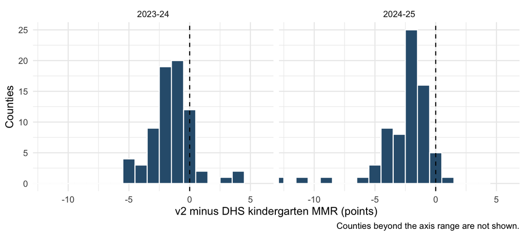

```r
wi |>
  filter(series == "Kindergarten MMR") |>
  ggplot(aes(diff)) +
  geom_histogram(binwidth = 1, fill = "#2f5d7c", colour = "white") +
  geom_vline(xintercept = 0, linetype = 2) +
  facet_wrap(~school_year) +
  coord_cartesian(xlim = c(-12, 6)) +
  labs(x = "v2 minus DHS kindergarten MMR (points)", y = "Counties",
       caption = "Counties beyond the axis range are not shown.") +
  theme_minimal(base_size = 12)
```

Statewide, the enrollment-weighted v2 mean matches CDC’s all-required estimate in 2021-22 and runs about 3 points below CDC’s MMR estimate afterwards:

```r
state_means("WI", "Wisconsin") |>
  filter(school_year >= "2021-22") |>
  transmute(school_year, weighted_mean = num(weighted_mean), cdc,
            foot_notes, v2_minus_cdc = num(v2_minus_cdc)) |>
  kable(col.names = c("School year", "v2 weighted mean", "CDC", "CDC footnotes", "v2 − CDC"))
```

| School year | v2 weighted mean | CDC | CDC footnotes | v2 − CDC |
| --- | --- | --- | --- | --- |
| 2021-22 | 82.4 | 82.6 | >=. ‡ | -0.2 |
| 2022-23 | 83.1 | 86.5 | ‡ | -3.4 |
| 2023-24 | 82.1 | 84.8 | ‡. § | -2.7 |
| 2024-25 | 81.4 | 84.8 | ‡. § | -3.4 |

CDC’s “≥” footnote marks an estimate that counts children up to date on all required vaccines.

## 2. Kentucky: v2 tracks CDC, including its measure

CDC publishes one kindergarten MMR estimate per state and year. For Kentucky in 2021-22 to 2023-24 it carries the “≥” footnote, so those estimates are all-required rates. The v2 values, labelled MMR, average to within 0.1 point of CDC from 2022-23 on, both while CDC is all-required and after it switches to MMR in 2024-25.

```r
state_means("KY", "Kentucky") |>
  filter(school_year >= "2021-22") |>
  transmute(school_year, counties, weighted_mean = num(weighted_mean),
            unweighted_mean = num(unweighted_mean), cdc, foot_notes,
            v2_minus_cdc = num(v2_minus_cdc)) |>
  kable(col.names = c("School year", "Counties", "v2 weighted mean", "Unweighted",
                      "CDC", "CDC footnotes", "v2 − CDC"))
```

| School year | Counties | v2 weighted mean | Unweighted | CDC | CDC footnotes | v2 − CDC |
| --- | --- | --- | --- | --- | --- | --- |
| 2021-22 | 120 | 88.0 | 88.6 | 86.5 | >=. ‡. § | 1.5 |
| 2022-23 | 120 | 90.2 | 91.3 | 90.1 | >=. ‡. § | 0.1 |
| 2023-24 | 120 | 90.1 | 91.1 | 90.0 | >=. *. ‡. § | 0.1 |
| 2024-25 | 119 | 87.0 | 91.2 | 86.9 | *. § | 0.1 |

## 3. Indiana: 2023-24 stands apart

In 2023-24 the v2 values sit about 3.6 points above CDC; in 2024-25 they agree. Weighting does not explain the gap: the unweighted mean and the median county are higher still.

```r
state_means("IN", "Indiana") |>
  filter(school_year >= "2021-22") |>
  transmute(school_year, counties, weighted_mean = num(weighted_mean),
            unweighted_mean = num(unweighted_mean), median_county = num(median_county),
            cdc, v2_minus_cdc = num(v2_minus_cdc)) |>
  kable(col.names = c("School year", "Counties", "v2 weighted mean", "Unweighted",
                      "Median county", "CDC", "v2 − CDC"))
```

| School year | Counties | v2 weighted mean | Unweighted | Median county | CDC | v2 − CDC |
| --- | --- | --- | --- | --- | --- | --- |
| 2023-24 | 92 | 94.4 | 94.8 | 95.3 | 90.8 | 3.6 |
| 2024-25 | 92 | 90.9 | 91.3 | 91.5 | 90.8 | 0.1 |

The drop from 2023-24 to 2024-25 is broad, not a few counties:

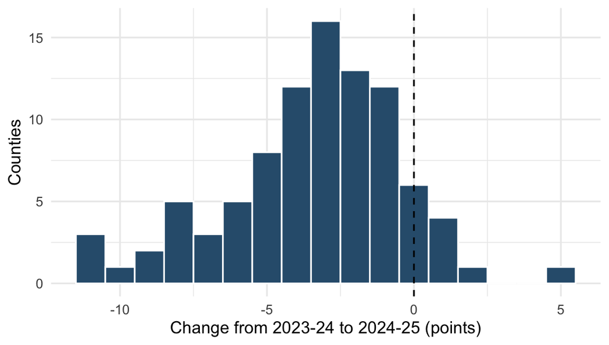

```r
ind <- hopkins |>
  filter(state == "IN", school_year %in% c("2023-24", "2024-25")) |>
  select(fips, school_year, v2) |>
  pivot_wider(names_from = school_year, values_from = v2) |>
  mutate(change = `2024-25` - `2023-24`)

ggplot(ind, aes(change)) +
  geom_histogram(binwidth = 1, fill = "#2f5d7c", colour = "white") +
  geom_vline(xintercept = 0, linetype = 2) +
  labs(x = "Change from 2023-24 to 2024-25 (points)", y = "Counties") +
  theme_minimal(base_size = 12)
```

86 of 92 counties fall, by a median of 3.2 points, while CDC’s estimate is unchanged at 90.8.

## 4. Idaho: a widening gap above CDC

```r
state_means("ID", "Idaho") |>
  filter(school_year >= "2021-22") |>
  transmute(school_year, counties, weighted_mean = num(weighted_mean), cdc,
            survey_type, v2_minus_cdc = num(v2_minus_cdc)) |>
  kable(col.names = c("School year", "Counties", "v2 weighted mean", "CDC",
                      "CDC collection", "v2 − CDC"))
```

| School year | Counties | v2 weighted mean | CDC | CDC collection | v2 − CDC |
| --- | --- | --- | --- | --- | --- |
| 2021-22 | 44 | 85.4 | 83.9 | Census | 1.5 |
| 2022-23 | 44 | 83.1 | 81.3 | Census | 1.8 |
| 2023-24 | 44 | 82.2 | 79.6 | Census | 2.6 |
| 2024-25 | 44 | 81.2 | 78.5 | Census | 2.7 |

Both series are census-based, yet v2 runs above CDC by 1.5 to 2.7 points, and the gap grows each year.

## Sources

- **Johns Hopkins county MMR data, v2 release:** `mmr_data_us_counties_v2.csv`, github.com/enshengdong/MMR_data at commit 219427a3.
- **Wisconsin DHS:** kindergarten immunization assessment by county, `p01892.xlsx` (tab “By County”), dhs.wisconsin.gov/publications/p01892.xlsx.
- **CDC SchoolVaxView:** kindergarten MMR coverage, data.cdc.gov dataset ijqb-a7ye.
- **Kindergarten enrollment:** NCES Common Core of Data (public schools) and Private School Survey, assigned to counties by school location.